# JOINING DATA WITH DPLYR: JOINING TABLES

The information for data analysis is not always confined in a data table. Often you’ll need to join multiple tables together, so that they can be analyzed in a combination.

### 5.1 The LEGO datasets

[figure not shown]

The LEGO dataset is about the construction toys known as LEGOs, which contains information about the sets, parts, themes, and colors that make up LEGO history. The dataset is spread across many tables.

```r
sets <- readRDS("sets.rds") # contains one row for each of the 4977 LEGO sets
```

Examine the table:

```r
head(sets)
```

```
##     set_num                                                      name year
## 1   700.3-1                                     Medium Gift Set (ABB) 1949
## 2 700.1.1-1                                  Single 2 x 4 Brick (ABB) 1950
## 3 700.B.2-1               Single 1 x 2 x 3 Window without Glass (ABB) 1950
## 4   700.1-2                            Extra-Large Gift Set (Mursten) 1953
## 5   700.F-1 Automatic Binding Bricks - Small Brick Set (Lego Mursten) 1953
## 6  700.24-1                                  Individual 2 x 12 Bricks 1954
##   theme_id
## 1      365
## 2      371
## 3      371
## 4      366
## 5      371
## 6      371
```

We see `theme_id` is not useful on its own. The useful information for `theme_id` is in another table called **themes**. Import and examine this table:

```r
themes <- readRDS("themes.rds")
head(themes)
```

```
##   id           name parent_id
## 1  1        Technic        NA
## 2  2 Arctic Technic         1
## 3  3    Competition         1
## 4  4 Expert Builder         1
## 5  5          Model         1
## 6  6        Airport         5
```

The `theme_id` variable in `sets` table links to the `id` variable in the `themes` table. For any individual set, we could find a theme that matches it.

### 5.2 Inner-join

To see the theme that each set is associated with, we will need to join the two tables with the `inner_join` verb from **dplyr** package.

Load the **dplyr** package:

```r
library(dplyr)
```

Use `inner_join` to join the table **sets** to the table **themes**:

```r
sets %>%
  inner_join(themes, by = c("theme_id" = "id"))
```

```
## # A tibble: 4,977 x 6
##    set_num   name.x                            year theme_id name.y    parent_id
##    <chr>     <chr>                            <dbl>    <dbl> <chr>         <dbl>
##  1 700.3-1   Medium Gift Set (ABB)             1949      365 System           NA
##  2 700.1.1-1 Single 2 x 4 Brick (ABB)          1950      371 Suppleme~       365
##  3 700.B.2-1 Single 1 x 2 x 3 Window without~  1950      371 Suppleme~       365
##  4 700.1-2   Extra-Large Gift Set (Mursten)    1953      366 Basic Set       365
##  5 700.F-1   Automatic Binding Bricks - Smal~  1953      371 Suppleme~       365
##  6 700.24-1  Individual 2 x 12 Bricks          1954      371 Suppleme~       365
##  7 700.C.1-1 Individual 1 x 6 x 4 Panorama W~  1954      371 Suppleme~       365
##  8 700.C.4-1 Individual 1 x 4 x 3 Window (wi~  1954      371 Suppleme~       365
##  9 700.H-1   Individual 4 x 4 Corner Bricks    1954      371 Suppleme~       365
## 10 1200-1    LEGO Town Plan Board, Large Pla~  1955      372 Town Plan       365
## # ... with 4,967 more rows
```

The argument `by` tells how to match the tables: linking `theme_id` in the first table to `id` in second table.

The output shows a combined table which combines each set with its theme. But because both variables have a variable called `name`, the new combined table results in `name.x` and `name.y`.

Customize `inner_join()` so that it is more readable:

```r
sets %>%
  inner_join(themes, by = c("theme_id" = "id"),
             suffix = c("_set", "_theme"))
```

```
## # A tibble: 4,977 x 6
##    set_num  name_set                          year theme_id name_theme parent_id
##    <chr>    <chr>                            <dbl>    <dbl> <chr>          <dbl>
##  1 700.3-1  Medium Gift Set (ABB)             1949      365 System            NA
##  2 700.1.1~ Single 2 x 4 Brick (ABB)          1950      371 Supplemen~       365
##  3 700.B.2~ Single 1 x 2 x 3 Window without~  1950      371 Supplemen~       365
##  4 700.1-2  Extra-Large Gift Set (Mursten)    1953      366 Basic Set        365
##  5 700.F-1  Automatic Binding Bricks - Smal~  1953      371 Supplemen~       365
##  6 700.24-1 Individual 2 x 12 Bricks          1954      371 Supplemen~       365
##  7 700.C.1~ Individual 1 x 6 x 4 Panorama W~  1954      371 Supplemen~       365
##  8 700.C.4~ Individual 1 x 4 x 3 Window (wi~  1954      371 Supplemen~       365
##  9 700.H-1  Individual 4 x 4 Corner Bricks    1954      371 Supplemen~       365
## 10 1200-1   LEGO Town Plan Board, Large Pla~  1955      372 Town Plan        365
## # ... with 4,967 more rows
```

Now we can answer interesting questions about the data. For example, find out the most common theme in LEGO:

```r
sets %>%
  inner_join(themes, by = c("theme_id" = "id"),
             suffix = c("_set", "_theme")) %>%
  count(name_theme, sort = TRUE)
```

```
## # A tibble: 419 x 2
##    name_theme        n
##    <chr>         <int>
##  1 Supplemental    180
##  2 Basic Set       171
##  3 Technic         144
##  4 Friends         133
##  5 Gear            122
##  6 City            120
##  7 Town            117
##  8 Ninjago          95
##  9 Service Packs    94
## 10 Star Wars        94
## # ... with 409 more rows
```

Import and examine two other tables of the LEGOs dataset: **parts** and **part_categories**. A part is a shape, like a gear, a brick or a figurine that assembles a LEGO toy.

```r
parts <- readRDS("parts.rds")
head(parts)
```

```
## # A tibble: 6 x 3
##   part_num name                                                   part_cat_id
##   <chr>    <chr>                                                        <dbl>
## 1 0901     Baseplate 16 x 30 with Set 080 Yellow House Print                1
## 2 0902     Baseplate 16 x 24 with Set 080 Small White House Print           1
## 3 0903     Baseplate 16 x 24 with Set 080 Red House Print                   1
## 4 0904     Baseplate 16 x 24 with Set 080 Large White House Print           1
## 5 1        Homemaker Bookcase 2 x 4 x 4                                     7
## 6 10016414 Sticker Sheet #1 for 41055-1                                    58
```

```r
part_categories <- readRDS("part_categories.rds")
head(part_categories)
```

```
## # A tibble: 6 x 2
##      id name
##   <dbl> <chr>
## 1     1 Baseplates
## 2     3 Bricks Sloped
## 3     4 Duplo, Quatro and Primo
## 4     5 Bricks Special
## 5     6 Bricks Wedged
## 6     7 Containers
```

The `part_cat_id variable` in **parts** table links to the `id` variable in the **part_categories** table. Join two tables and add a suffix to distinguish the names:

```r
parts %>%
  inner_join(part_categories, by = c("part_cat_id" = "id"),
             suffix = c("_part", "_category"))
```

```
## # A tibble: 17,501 x 4
##    part_num   name_part                             part_cat_id name_category
##    <chr>      <chr>                                       <dbl> <chr>
##  1 0901       Baseplate 16 x 30 with Set 080 Yello~           1 Baseplates
##  2 0902       Baseplate 16 x 24 with Set 080 Small~           1 Baseplates
##  3 0903       Baseplate 16 x 24 with Set 080 Red H~           1 Baseplates
##  4 0904       Baseplate 16 x 24 with Set 080 Large~           1 Baseplates
##  5 1          Homemaker Bookcase 2 x 4 x 4                    7 Containers
##  6 10016414   Sticker Sheet #1 for 41055-1                   58 Stickers
##  7 10026stk01 Sticker for Set 10026 - (44942/41841~          58 Stickers
##  8 10039      Pullback Motor 8 x 4 x 2/3                     44 Mechanical
##  9 10048      Minifig Hair Tousled                           65 Minifig Headwear
## 10 10049      Minifig Shield Broad with Spiked Bot~          27 Minifig Accesso~
## # ... with 17,491 more rows
```

### 5.3 Joining with a one-to-many relationship

Not all the tables have exactly the same observations like **sets** and **themes**, or **parts** and **part_categories**. Import and examine a new table, **inventories**:

```r
inventories <- readRDS("inventories.rds")
```

An inventory represents a product that’s made up of some combination of parts.

```r
head(inventories)
```

```
## # A tibble: 6 x 3
##      id version set_num
##   <dbl>   <dbl> <chr>
## 1     1       1 7922-1
## 2     3       1 3931-1
## 3     4       1 6942-1
## 4    15       1 5158-1
## 5    16       1 903-1
## 6    17       1 850950-1
```

`set_num` variable suggests it links to the **sets** table. So we inner_join **sets** to **inventories**:

```r
sets %>%
  inner_join(inventories, by = "set_num") # when the joining variables have the same name.
```

```
## # A tibble: 5,056 x 6
##    set_num   name                                    year theme_id    id version
##    <chr>     <chr>                                  <dbl>    <dbl> <dbl>   <dbl>
##  1 700.3-1   Medium Gift Set (ABB)                   1949      365 24197       1
##  2 700.3-1   Medium Gift Set (ABB)                   1949      365 24214       2
##  3 700.3-1   Medium Gift Set (ABB)                   1949      365 24215       3
##  4 700.1.1-1 Single 2 x 4 Brick (ABB)                1950      371 11831       1
##  5 700.1.1-1 Single 2 x 4 Brick (ABB)                1950      371 24230       2
##  6 700.1.1-1 Single 2 x 4 Brick (ABB)                1950      371 24231       3
##  7 700.1.1-1 Single 2 x 4 Brick (ABB)                1950      371 24232       4
##  8 700.1.1-1 Single 2 x 4 Brick (ABB)                1950      371 24233       5
##  9 700.B.2-1 Single 1 x 2 x 3 Window without Glass~  1950      371   537       1
## 10 700.B.2-1 Single 1 x 2 x 3 Window without Glass~  1950      371 24240       2
## # ... with 5,046 more rows
```

The **sets** table starts with 4977 observations, but after joining now has 5056, because each set can have multiple versions, each of which gets its own inventory item. Filter this joined table for only the first version:

```r
sets %>%
  inner_join(inventories, by = "set_num") %>%
  filter(version == 1)
```

```
## # A tibble: 4,976 x 6
##    set_num   name                                    year theme_id    id version
##    <chr>     <chr>                                  <dbl>    <dbl> <dbl>   <dbl>
##  1 700.3-1   Medium Gift Set (ABB)                   1949      365 24197       1
##  2 700.1.1-1 Single 2 x 4 Brick (ABB)                1950      371 11831       1
##  3 700.B.2-1 Single 1 x 2 x 3 Window without Glass~  1950      371   537       1
##  4 700.1-2   Extra-Large Gift Set (Mursten)          1953      366 12985       1
##  5 700.F-1   Automatic Binding Bricks - Small Bric~  1953      371 11265       1
##  6 700.24-1  Individual 2 x 12 Bricks                1954      371  7645       1
##  7 700.C.1-1 Individual 1 x 6 x 4 Panorama Window ~  1954      371  3896       1
##  8 700.C.4-1 Individual 1 x 4 x 3 Window (with gla~  1954      371  3663       1
##  9 700.H-1   Individual 4 x 4 Corner Bricks          1954      371 15503       1
## 10 1200-1    LEGO Town Plan Board, Large Plastic     1955      372 10761       1
## # ... with 4,966 more rows
```

The result is a table with 4976 observations, compared to 4977 in **sets** table. This means there is one set that doesn’t have version 1, which is probably a data quality issue.

An `inner_join` keeps only an observation if it has an exact match between the first and the second tables. Paying attention to the number of rows before and after a join is an important part of understanding data.

Each LEGO piece has another attribute besides its part, its color, which are found in **inventory_parts** table.

[figure not shown]

Import and examine this table:

```r
inventory_parts <- readRDS("inventory_parts.rds")
head(inventory_parts)
```

```
## # A tibble: 6 x 4
##   inventory_id part_num             color_id quantity
##          <dbl> <chr>                   <dbl>    <dbl>
## 1           21 3009                        7       50
## 2           25 21019c00pat004pr1033       15        1
## 3           25 24629pr0002                78        1
## 4           25 24634pr0001                 5        1
## 5           25 24782pr0001                 5        1
## 6           25 88646                       0        1
```

The colors table tells the color of each part in each set:

```r
colors <- readRDS("colors.rds")
head(colors)
```

```
## # A tibble: 6 x 3
##      id name           rgb
##   <dbl> <chr>          <chr>
## 1    -1 [Unknown]      #0033B2
## 2     0 Black          #05131D
## 3     1 Blue           #0055BF
## 4     2 Green          #237841
## 5     3 Dark Turquoise #008F9B
## 6     4 Red            #C91A09
```

Connect the **parts** and **inventory_parts** tables by their part numbers:

```r
parts %>%
  inner_join(inventory_parts, by = "part_num") # results in one-to-many relationship.
```

```
## # A tibble: 258,958 x 6
##    part_num name                      part_cat_id inventory_id color_id quantity
##    <chr>    <chr>                           <dbl>        <dbl>    <dbl>    <dbl>
##  1 0901     Baseplate 16 x 30 with S~           1         1973        2        1
##  2 0902     Baseplate 16 x 24 with S~           1         1973        2        1
##  3 0903     Baseplate 16 x 24 with S~           1         1973        2        1
##  4 0904     Baseplate 16 x 24 with S~           1         1973        2        1
##  5 1        Homemaker Bookcase 2 x 4~           7          508       15        1
##  6 1        Homemaker Bookcase 2 x 4~           7         1158       15        2
##  7 1        Homemaker Bookcase 2 x 4~           7         6590       15        2
##  8 1        Homemaker Bookcase 2 x 4~           7         9679       15        2
##  9 1        Homemaker Bookcase 2 x 4~           7        12256        1        2
## 10 1        Homemaker Bookcase 2 x 4~           7        13356       15        1
## # ... with 258,948 more rows
```

An `inner_join` works the same way with either table in either position.

```r
inventory_parts %>%
  inner_join(parts, by = "part_num")
```

```
## # A tibble: 258,958 x 6
##    inventory_id part_num    color_id quantity name                   part_cat_id
##           <dbl> <chr>          <dbl>    <dbl> <chr>                        <dbl>
##  1           21 3009               7       50 Brick 1 x 6                     11
##  2           25 21019c00pa~       15        1 Legs and Hips with Bl~          61
##  3           25 24629pr0002       78        1 Minifig Head Special ~          59
##  4           25 24634pr0001        5        1 Headwear Accessory Bo~          27
##  5           25 24782pr0001        5        1 Minifig Hipwear Skirt~          27
##  6           25 88646              0        1 Tile Special 4 x 3 wi~          15
##  7           25 973pr3314c~        5        1 Torso with 1 White Bu~          60
##  8           26 14226c11           0        3 String with End Studs~          31
##  9           26 2340px2           15        1 Tail 4 x 1 x 3 with '~          35
## 10           26 2340px3           15        1 Tail 4 x 1 x 3 with '~          35
## # ... with 258,948 more rows
```

This returns the same join, but the order of the tables is reversed. the columns will appear in a different order depending on which table comes first.

### 5.4 Joining three or more tables

Multiple tables could be joined using `inner_join` and pipe `%>%`

```r
sets %>%
  inner_join(inventories, by = "set_num") %>%
  inner_join(themes, by = c("theme_id" = "id"),
             suffix = c("_set","_theme"))
```

```
## # A tibble: 5,056 x 8
##    set_num  name_set            year theme_id    id version name_theme parent_id
##    <chr>    <chr>              <dbl>    <dbl> <dbl>   <dbl> <chr>          <dbl>
##  1 700.3-1  Medium Gift Set (~  1949      365 24197       1 System            NA
##  2 700.3-1  Medium Gift Set (~  1949      365 24214       2 System            NA
##  3 700.3-1  Medium Gift Set (~  1949      365 24215       3 System            NA
##  4 700.1.1~ Single 2 x 4 Bric~  1950      371 11831       1 Supplemen~       365
##  5 700.1.1~ Single 2 x 4 Bric~  1950      371 24230       2 Supplemen~       365
##  6 700.1.1~ Single 2 x 4 Bric~  1950      371 24231       3 Supplemen~       365
##  7 700.1.1~ Single 2 x 4 Bric~  1950      371 24232       4 Supplemen~       365
##  8 700.1.1~ Single 2 x 4 Bric~  1950      371 24233       5 Supplemen~       365
##  9 700.B.2~ Single 1 x 2 x 3 ~  1950      371   537       1 Supplemen~       365
## 10 700.B.2~ Single 1 x 2 x 3 ~  1950      371 24240       2 Supplemen~       365
## # ... with 5,046 more rows
```

In a series of joins, each will usually has different `by` arguments, and often they will have different suffix arguments, depending on the details of the tables you are joining.

Now connect **sets**, a table that tells us about each LEGO kit, with **inventories**, a table that tells us the specific version of a given set, and finally to **inventory_parts**, a table which tells us how many of each part is available in each LEGO kit, and colors.

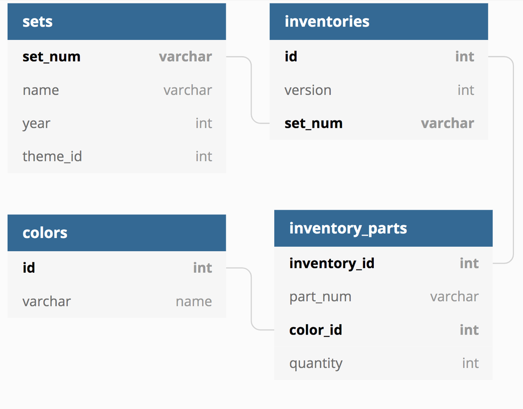

This will let us answer question like “what are the most common colors of parts in LEGO sets?”

```r
sets %>%
  inner_join(inventories, by = "set_num") %>%
  inner_join(inventory_parts, by = c("id" = "inventory_id")) %>%
  inner_join(colors, by = c("color_id" = "id"), suffix = c("_set", "_color")) %>%
  count(name_color, sort = TRUE)
```

```
## # A tibble: 134 x 2
##    name_color            n
##    <chr>             <int>
##  1 Black             48068
##  2 White             30105
##  3 Light Bluish Gray 26024
##  4 Red               21602
##  5 Dark Bluish Gray  19948
##  6 Yellow            17088
##  7 Blue              12980
##  8 Light Gray         8632
##  9 Reddish Brown      6960
## 10 Tan                6664
## # ... with 124 more rows
```

You will also get accustomed to working with data that spans a large number of tables.